# PART 1 : Question Based Assignment

## Question 1: Please refer the table below to answer below questions:

Planned to purchase Actually placed-Yes Actually placed-No Total Yes 400 100 500 No 200 1300 1500 Total 600 1400 2000

1. Refer to the above table and find the joint probability of the people who planned to purchase and actually placed an order.
1. Refer to the above table and find the joint probability of the people who planned to purchase and actually placed an order, given that people planned to purchase.

### Ans Q1:

#### 1. Joint probability of the people who planned to purchase and actually placed an order.

Total People: 2000 People who purchased out of those of planned to purchase: 400

Probability of people who planned to purchase and actuall placed an order = 400/2000 = 0.2

#### 2. Joint probability of the people who planned to purchase and actually placed an order, given that people planned to purchase.

People who placed planned to purchase: 500 People who purchased out of those of planned to purchase: 400

Probability of people who planned to purchase and actuall placed an order given that people planned to purchase = 400/500 = 0.8

## Question 2: An electrical manufacturing company conducts quality checks at specified periods on the products it manufactures. Historically, the failure rate for the manufactured item is 5%. Suppose a random sample of 10 manufactured items is selected. Answer the following questions.

A. Probability that none of the items are defective?

B. Probability that exactly one of the items is defective?

C. Probability that two or fewer of the items are defective?

D. Probability that three or more of the items are defective ?

```python
import numpy as np
import scipy.stats as stats

n=10 ## Number of samples
p=0.05 ## Failure rate
k=np.arange (0,11) ## Total 11 probabilities (including the first with 0)
k
```

```
array([ 0,  1,  2,  3,  4,  5,  6,  7,  8,  9, 10])
```

```python
binomial = stats.binom.pmf(k,n,p)
```

```python
## Answer to A : Probability that none of the items are defective
Pa = binomial[0]
print ("Answer to Q1.A : Probability that none of the items are defective:", Pa)

## Answer to B : Probability that exactly one of the items is defective
Pb = binomial [1]
print ("Answer to Q1.B : Probability that exactly one of the items are defective:", Pb)

## Answer to C : Probability that two or fewer of the items are defective
Pc = binomial[0]+binomial[1]+binomial[2]
print ("Answer to Q1.C : Probability that two or fewer of the items are defective:", Pc)

## Answer to D : Probability that three or more of the items are defective
Pd = 1 - Pc
print ("Answer to Q1.D : Probability that two or fewer of the items are defective:", Pd)
```

```
Answer to Q1.A : Probability that none of the items are defective: 0.5987369392383789
Answer to Q1.B : Probability that exactly one of the items are defective: 0.31512470486230504
Answer to Q1.C : Probability that two or fewer of the items are defective: 0.9884964426207035
Answer to Q1.D : Probability that two or fewer of the items are defective: 0.011503557379296536
```

## Question 3: A car salesman sells on an average 3 cars per week.

A. Probability that in a given week he will sell some cars.

B. Probability that in a given week he will sell 2 or more but less than 5 cars.

C. Plot the poisson distribution function for cumulative probability of cars sold per-week vs number of cars sold perweek.

```python
import numpy as np
import scipy.stats as stats
import matplotlib.pyplot as plt

#average rate, denoted with lambda in the formula for poisson distribution

rate = 3

#numpy array of different no. of successes ranging from 0 to 50 to construct a probability distribution

n=np.arange(0,50)

#calculating the distribution and storing the distribution of probablitites in an array
poisson = stats.poisson.pmf(n,rate)

# ANS A: Probability that in a given week he will sell some cars. 1 - Probability of selling 0 cars
Pa = 1 - poisson[0]
print("Answer for Q3:A: Probability that in a given week he will sell some cars: ", Pa)

# ANS B: Probability that in a given week he will sell 2 or more but less than 5 cars
# This is the sum of probabilities for selling 2, 3 and 4 cars per week
Pb = poisson[2]+poisson[3]+ poisson[4]
print("Answer for Q3:B: Probability that in a given week he will sell 2 or more but less than 5 cars: ", Pb)
```

```
Answer for Q3:A: Probability that in a given week he will sell some cars:  0.950212931632136
Answer for Q3:B: Probability that in a given week he will sell 2 or more but less than 5 cars:  0.6161149710523164
```

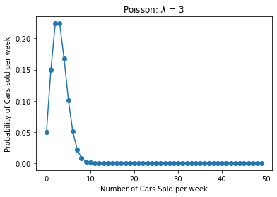

```python
#Plot the poisson distribution function for cumulative probability of cars sold per-week vs number of cars sold perweek.
plt.plot(n,poisson,'o-')
plt.title('Poisson: $\lambda$ = %i ' % rate)
plt.xlabel('Number of Cars Sold per week')
plt.ylabel('Probability of Cars sold per week')
plt.show()
```

## Question 4: Accuracy in understanding orders for a speech based bot at a restaurant is important for the Company X which has designed, marketed and launched the product for a contactless delivery due to the COVID-19 pandemic. Recognition accuracy that measures the percentage of orders that are taken correctly is 86.8%. Suppose that you place order with the bot and two friends of yours independently place orders with the same bot. Answer the following questions.

A. What is the probability that all three orders will be recognised correctly?

B. What is the probability that none of the three orders will be recognised correctly?

C. What is the probability that at least two of the three orders will be recognised correctly?

```python
# This is an example of Binomial distribution

import numpy as np
import scipy.stats as stats

n=3 ## Number of samples
p=0.86 ## Success rate
k=np.arange (0,4)

binomial = stats.binom.pmf(k,n,p)

#A. What is the probability that all three orders will be recognised correctly?
Pa = binomial[3]
print("Ans Q3A: Probability of All three orders being recognised correctly: ", Pa)

#B. What is the probability that none of the three orders will be recognised correctly?
Pb = binomial[0]
print("Ans Q3B: Probability of none of the orders being recognised correctly: ", Pb)

#C. What is the probability that at least two of the three orders will be recognised correctly?
Pc = binomial[2] + binomial[3]
print("Ans Q3C: Probability of at least two orders being recognised correctly: ", Pc)
```

```
Ans Q3A: Probability of All three orders being recognised correctly:  0.636056
Ans Q3B: Probability of none of the orders being recognised correctly:  0.0027440000000000008
Ans Q3C: Probability of at least two orders being recognised correctly:  0.9466879999999999
```

## Question 5: A group of 300 professionals sat for a competitive exam. The results show the information of marks obtained by them have a mean of 60 and a standard deviation of 12. The pattern of marks follows a normal distribution. Answer the following questions.

A. What is the percentage of students who score more than 80.

B. What is the percentage of students who score less than 50.

C. What should be the distinction mark if the highest 10% of students are to be awarded distinction?

```python
import numpy as np
import scipy.stats as stats

#ANS for part A:

# This is the normal distribution with mean as 60 and standard deviation as 12.
# To calculate the probability of population more than 80, calculate the probability to the left.
# Subtract that figure from 1 to get the probability for the value to the right of 80.
Pa = 1 - stats.norm.cdf (80,loc=60, scale=12)

print("ANS Q5A: percentage of students who score more than 80:", Pa*100)



#ANS for part B:

Pb = stats.norm.cdf (50,loc=60, scale=12)
print("ANS Q5B: percentage of students who score less than 50:", Pb*100)

#ANS for Part C:
# Use norm.ppf function to identify the value on curve for 90% on the curve

DistMark = stats.norm.ppf (0.90, 60, 12)

print("ANS Q5C: Distinction Mark for upper 10% students", DistMark)
```

```
ANS Q5A: percentage of students who score more than 80: 4.77903522728147
ANS Q5B: percentage of students who score less than 50: 20.232838096364308
ANS Q5C: Distinction Mark for upper 10% students 75.3786187865352
```

## Question 6: Explain 1 real life industry scenario [other than the ones mentioned above] where you can use the concepts learnt in this module of Applied statistics to get a data driven business solution.

##### In the IT firms, the HR department and the Senior management keeps track of Employee activities. Typically below datapoints are available and can be calculated on a per day basis frequency:

- Employee login time and logoff time
- Region/City/Country of the employee
- The productivity of the employee calculated using his repository checkins activity. (Standard tools like BlueOptima are available forthis purpose)
- Employee planned/unplanned leaves.
- Employee working remotely or from office (on a particular date).

##### A set of this data points can be collated and lots of insights can be derived out of it. Few of them as below:

- Employee working hours per country/region.
- Productivity of the employee when he/she is working remotely v.s. from office.
- Typical leave zones per country / City (periods where high proportions of people are on leave per City/Country).

##### Using both descriptive as well as inference based statistics, these (and lot more )patterns can be observed using which Senior management can plan their strategy.

- For example, during a certain period, leave probability is higher so accordingly release calander can be defined.
- The productivity of people working remotely can be analysed and accordingly the policy for working remotely can be decided.

# PART 2 : Project Based Assignment

## 1. Read the CSV File

```python
import numpy as np
import pandas as pd
import matplotlib.pyplot as plt

bbdata = pd.read_csv("DS - Part2 - Basketball.csv")
```

## 2. Data Exploration

```python
bbdata.head(5)
```

|  | Team | Tournament | Score | PlayedGames | WonGames | DrawnGames | LostGames | BasketScored | BasketGiven | TournamentChampion | Runner-up | TeamLaunch | HighestPositionHeld |
| --- | --- | --- | --- | --- | --- | --- | --- | --- | --- | --- | --- | --- | --- |
| 0 | Team 1 | 86 | 4385 | 2762 | 1647 | 552 | 563 | 5947 | 3140 | 33 | 23 | 1929 | 1 |
| 1 | Team 2 | 86 | 4262 | 2762 | 1581 | 573 | 608 | 5900 | 3114 | 25 | 25 | 1929 | 1 |
| 2 | Team 3 | 80 | 3442 | 2614 | 1241 | 598 | 775 | 4534 | 3309 | 10 | 8 | 1929 | 1 |
| 3 | Team 4 | 82 | 3386 | 2664 | 1187 | 616 | 861 | 4398 | 3469 | 6 | 6 | 1931to32 | 1 |
| 4 | Team 5 | 86 | 3368 | 2762 | 1209 | 633 | 920 | 4631 | 3700 | 8 | 7 | 1929 | 1 |

```python
bbdata.tail(5)
```

|  | Team | Tournament | Score | PlayedGames | WonGames | DrawnGames | LostGames | BasketScored | BasketGiven | TournamentChampion | Runner-up | TeamLaunch | HighestPositionHeld |
| --- | --- | --- | --- | --- | --- | --- | --- | --- | --- | --- | --- | --- | --- |
| 56 | Team 57 | 1 | 34 | 38 | 8 | 10 | 20 | 38 | 66 | - | - | 2009-10 | 20 |
| 57 | Team 58 | 1 | 22 | 30 | 7 | 8 | 15 | 37 | 57 | - | - | 1956-57 | 16 |
| 58 | Team 59 | 1 | 19 | 30 | 7 | 5 | 18 | 51 | 85 | - | - | 1951~52 | 16 |
| 59 | Team 60 | 1 | 14 | 30 | 5 | 4 | 21 | 34 | 65 | - | - | 1955-56 | 15 |
| 60 | Team 61 | 1 | - | - | - | - | - | - | - | - | - | 2017~18 | 9 |

```python
## Remove the footer to get rid off the junk line at the end for Team 61
bbdata = pd.read_csv("DS - Part2 - Basketball.csv",skipfooter=1)
```

```python
bbdata.info()
```

```
<class 'pandas.core.frame.DataFrame'>
RangeIndex: 60 entries, 0 to 59
Data columns (total 13 columns):
 #   Column               Non-Null Count  Dtype
---  ------               --------------  -----
 0   Team                 60 non-null     object
 1   Tournament           60 non-null     int64
 2   Score                60 non-null     int64
 3   PlayedGames          60 non-null     int64
 4   WonGames             60 non-null     int64
 5   DrawnGames           60 non-null     int64
 6   LostGames            60 non-null     int64
 7   BasketScored         60 non-null     int64
 8   BasketGiven          60 non-null     int64
 9   TournamentChampion   60 non-null     object
 10  Runner-up            60 non-null     object
 11  TeamLaunch           60 non-null     object
 12  HighestPositionHeld  60 non-null     int64
dtypes: int64(9), object(4)
memory usage: 6.2+ KB
```

```python
bbdata.mean()
```

```
Tournament               24.383333
Score                   916.450000
PlayedGames             810.100000
WonGames                309.033333
DrawnGames              192.083333
LostGames               308.816667
BasketScored           1159.350000
BasketGiven            1159.233333
HighestPositionHeld       7.050000
dtype: float64
```

```python
bbdata.describe()
```

|  | Tournament | Score | PlayedGames | WonGames | DrawnGames | LostGames | BasketScored | BasketGiven | HighestPositionHeld |
| --- | --- | --- | --- | --- | --- | --- | --- | --- | --- |
| count | 60.000000 | 60.000000 | 60.000000 | 60.000000 | 60.000000 | 60.000000 | 60.000000 | 60.000000 | 60.000000 |
| mean | 24.383333 | 916.450000 | 810.100000 | 309.033333 | 192.083333 | 308.816667 | 1159.350000 | 1159.233333 | 7.050000 |
| std | 26.884620 | 1138.342899 | 877.465393 | 408.481395 | 201.985508 | 294.508639 | 1512.063948 | 1163.946914 | 5.315232 |
| min | 1.000000 | 14.000000 | 30.000000 | 5.000000 | 4.000000 | 15.000000 | 34.000000 | 55.000000 | 1.000000 |
| 25% | 4.000000 | 104.250000 | 115.500000 | 34.750000 | 26.250000 | 62.750000 | 154.500000 | 236.000000 | 3.000000 |
| 50% | 12.000000 | 395.500000 | 424.500000 | 124.000000 | 98.500000 | 197.500000 | 444.000000 | 632.500000 | 6.000000 |
| 75% | 39.000000 | 1360.500000 | 1345.500000 | 432.750000 | 331.500000 | 563.500000 | 1669.750000 | 2001.250000 | 10.000000 |
| max | 86.000000 | 4385.000000 | 2762.000000 | 1647.000000 | 633.000000 | 1070.000000 | 5947.000000 | 3889.000000 | 20.000000 |

## 3. Data Preprocessing and Visualisation

```python
## Observe and remove duplicates (if any)
dupes = bbdata.duplicated()
sum(dupes)
```

```
0
```

```python
##No Duplicates
```

```python
# Replace - with 0 as a prt of preprocessing
# - is observed in lot of numerical columns and hence it's a bulk replace in the data frame
bbdata = bbdata.replace(to_replace = "-", value = 0)
bbdata.info()
```

```
<class 'pandas.core.frame.DataFrame'>
RangeIndex: 60 entries, 0 to 59
Data columns (total 13 columns):
 #   Column               Non-Null Count  Dtype
---  ------               --------------  -----
 0   Team                 60 non-null     object
 1   Tournament           60 non-null     int64
 2   Score                60 non-null     int64
 3   PlayedGames          60 non-null     int64
 4   WonGames             60 non-null     int64
 5   DrawnGames           60 non-null     int64
 6   LostGames            60 non-null     int64
 7   BasketScored         60 non-null     int64
 8   BasketGiven          60 non-null     int64
 9   TournamentChampion   60 non-null     object
 10  Runner-up            60 non-null     object
 11  TeamLaunch           60 non-null     object
 12  HighestPositionHeld  60 non-null     int64
dtypes: int64(9), object(4)
memory usage: 6.2+ KB
```

```python
## Convert string columns to numerical
bbdata[['Runner-up']] = bbdata[['Runner-up']].apply(pd.to_numeric)
bbdata[['TournamentChampion']] = bbdata[['TournamentChampion']].apply(pd.to_numeric)
bbdata.info()
```

```
<class 'pandas.core.frame.DataFrame'>
RangeIndex: 60 entries, 0 to 59
Data columns (total 13 columns):
 #   Column               Non-Null Count  Dtype
---  ------               --------------  -----
 0   Team                 60 non-null     object
 1   Tournament           60 non-null     int64
 2   Score                60 non-null     int64
 3   PlayedGames          60 non-null     int64
 4   WonGames             60 non-null     int64
 5   DrawnGames           60 non-null     int64
 6   LostGames            60 non-null     int64
 7   BasketScored         60 non-null     int64
 8   BasketGiven          60 non-null     int64
 9   TournamentChampion   60 non-null     int64
 10  Runner-up            60 non-null     int64
 11  TeamLaunch           60 non-null     object
 12  HighestPositionHeld  60 non-null     int64
dtypes: int64(11), object(2)
memory usage: 6.2+ KB
```

```python
## Clean up the date column - TeamLaunch by reading first 4 data digits and then convert column to numerical
bbdata['TeamLaunch'] = bbdata['TeamLaunch'].str.extract(r'^(\d{4})', expand=False)
bbdata[['TeamLaunch']] = bbdata[['TeamLaunch']].apply(pd.to_numeric)
```

```python
## Validate the conversion is reflected correctly
bbdata.tail(5)
```

|  | Team | Tournament | Score | PlayedGames | WonGames | DrawnGames | LostGames | BasketScored | BasketGiven | TournamentChampion | Runner-up | TeamLaunch | HighestPositionHeld |
| --- | --- | --- | --- | --- | --- | --- | --- | --- | --- | --- | --- | --- | --- |
| 55 | Team 56 | 1 | 35 | 38 | 8 | 11 | 19 | 36 | 55 | 0 | 0 | 2016 | 17 |
| 56 | Team 57 | 1 | 34 | 38 | 8 | 10 | 20 | 38 | 66 | 0 | 0 | 2009 | 20 |
| 57 | Team 58 | 1 | 22 | 30 | 7 | 8 | 15 | 37 | 57 | 0 | 0 | 1956 | 16 |
| 58 | Team 59 | 1 | 19 | 30 | 7 | 5 | 18 | 51 | 85 | 0 | 0 | 1951 | 16 |
| 59 | Team 60 | 1 | 14 | 30 | 5 | 4 | 21 | 34 | 65 | 0 | 0 | 1955 | 15 |

```python
bbdata.info()
```

```
<class 'pandas.core.frame.DataFrame'>
RangeIndex: 60 entries, 0 to 59
Data columns (total 13 columns):
 #   Column               Non-Null Count  Dtype
---  ------               --------------  -----
 0   Team                 60 non-null     object
 1   Tournament           60 non-null     int64
 2   Score                60 non-null     int64
 3   PlayedGames          60 non-null     int64
 4   WonGames             60 non-null     int64
 5   DrawnGames           60 non-null     int64
 6   LostGames            60 non-null     int64
 7   BasketScored         60 non-null     int64
 8   BasketGiven          60 non-null     int64
 9   TournamentChampion   60 non-null     int64
 10  Runner-up            60 non-null     int64
 11  TeamLaunch           60 non-null     int64
 12  HighestPositionHeld  60 non-null     int64
dtypes: int64(12), object(1)
memory usage: 6.2+ KB
```

## 4. Statistical Analysis

```python
## Add three variables to the dataframe.
##These variables will hold the value of average win, average loss, average draw per game for each team.

bbdata['AverageWins'] = bbdata['WonGames']/bbdata['PlayedGames']
bbdata['AverageLoss'] = bbdata['LostGames']/bbdata['PlayedGames']
bbdata['AverageDraws'] = bbdata['LostGames']/bbdata['PlayedGames']
bbdata.info()
```

```
<class 'pandas.core.frame.DataFrame'>
RangeIndex: 60 entries, 0 to 59
Data columns (total 16 columns):
 #   Column               Non-Null Count  Dtype
---  ------               --------------  -----
 0   Team                 60 non-null     object
 1   Tournament           60 non-null     int64
 2   Score                60 non-null     int64
 3   PlayedGames          60 non-null     int64
 4   WonGames             60 non-null     int64
 5   DrawnGames           60 non-null     int64
 6   LostGames            60 non-null     int64
 7   BasketScored         60 non-null     int64
 8   BasketGiven          60 non-null     int64
 9   TournamentChampion   60 non-null     int64
 10  Runner-up            60 non-null     int64
 11  TeamLaunch           60 non-null     int64
 12  HighestPositionHeld  60 non-null     int64
 13  AverageWins          60 non-null     float64
 14  AverageLoss          60 non-null     float64
 15  AverageDraws         60 non-null     float64
dtypes: float64(3), int64(12), object(1)
memory usage: 7.6+ KB
```

```python
bbdata.corr()
```

|  | Tournament | Score | PlayedGames | WonGames | DrawnGames | LostGames | BasketScored | BasketGiven | TournamentChampion | Runner-up | TeamLaunch | HighestPositionHeld | AverageWins | AverageLoss | AverageDraws |
| --- | --- | --- | --- | --- | --- | --- | --- | --- | --- | --- | --- | --- | --- | --- | --- |
| Tournament | 1.000000 | 0.981258 | 0.998683 | 0.971749 | 0.989295 | 0.949350 | 0.974867 | 0.987781 | 0.589304 | 0.645924 | -0.599166 | -0.708002 | 0.819559 | -0.761297 | -0.761297 |
| Score | 0.981258 | 1.000000 | 0.979687 | 0.997232 | 0.958090 | 0.878780 | 0.996634 | 0.943801 | 0.715014 | 0.764819 | -0.538542 | -0.669215 | 0.877385 | -0.809566 | -0.809566 |
| PlayedGames | 0.998683 | 0.979687 | 1.000000 | 0.967486 | 0.993972 | 0.955925 | 0.969970 | 0.990020 | 0.575072 | 0.633101 | -0.581243 | -0.711065 | 0.813179 | -0.767913 | -0.767913 |
| WonGames | 0.971749 | 0.997232 | 0.967486 | 1.000000 | 0.939416 | 0.851436 | 0.999312 | 0.925745 | 0.752904 | 0.797849 | -0.540421 | -0.647819 | 0.884278 | -0.802821 | -0.802821 |
| DrawnGames | 0.989295 | 0.958090 | 0.993972 | 0.939416 | 1.000000 | 0.972786 | 0.942234 | 0.992479 | 0.503378 | 0.566021 | -0.570175 | -0.720248 | 0.774416 | -0.757461 | -0.757461 |
| LostGames | 0.949350 | 0.878780 | 0.955925 | 0.851436 | 0.972786 | 1.000000 | 0.857843 | 0.985041 | 0.324025 | 0.391645 | -0.591571 | -0.726172 | 0.665366 | -0.655055 | -0.655055 |
| BasketScored | 0.974867 | 0.996634 | 0.969970 | 0.999312 | 0.942234 | 0.857843 | 1.000000 | 0.931079 | 0.743847 | 0.791041 | -0.550150 | -0.648672 | 0.879124 | -0.795043 | -0.795043 |
| BasketGiven | 0.987781 | 0.943801 | 0.990020 | 0.925745 | 0.992479 | 0.985041 | 0.931079 | 1.000000 | 0.471618 | 0.533448 | -0.608902 | -0.727323 | 0.757279 | -0.717092 | -0.717092 |
| TournamentChampion | 0.589304 | 0.715014 | 0.575072 | 0.752904 | 0.503378 | 0.324025 | 0.743847 | 0.471618 | 1.000000 | 0.971533 | -0.286768 | -0.304307 | 0.765351 | -0.638581 | -0.638581 |
| Runner-up | 0.645924 | 0.764819 | 0.633101 | 0.797849 | 0.566021 | 0.391645 | 0.791041 | 0.533448 | 0.971533 | 1.000000 | -0.317250 | -0.359191 | 0.801247 | -0.677121 | -0.677121 |
| TeamLaunch | -0.599166 | -0.538542 | -0.581243 | -0.540421 | -0.570175 | -0.591571 | -0.550150 | -0.608902 | -0.286768 | -0.317250 | 1.000000 | 0.599679 | -0.491259 | 0.201751 | 0.201751 |
| HighestPositionHeld | -0.708002 | -0.669215 | -0.711065 | -0.647819 | -0.720248 | -0.726172 | -0.648672 | -0.727323 | -0.304307 | -0.359191 | 0.599679 | 1.000000 | -0.737288 | 0.661382 | 0.661382 |
| AverageWins | 0.819559 | 0.877385 | 0.813179 | 0.884278 | 0.774416 | 0.665366 | 0.879124 | 0.757279 | 0.765351 | 0.801247 | -0.491259 | -0.737288 | 1.000000 | -0.851444 | -0.851444 |
| AverageLoss | -0.761297 | -0.809566 | -0.767913 | -0.802821 | -0.757461 | -0.655055 | -0.795043 | -0.717092 | -0.638581 | -0.677121 | 0.201751 | 0.661382 | -0.851444 | 1.000000 | 1.000000 |
| AverageDraws | -0.761297 | -0.809566 | -0.767913 | -0.802821 | -0.757461 | -0.655055 | -0.795043 | -0.717092 | -0.638581 | -0.677121 | 0.201751 | 0.661382 | -0.851444 | 1.000000 | 1.000000 |

```python
## Strong corelation between Averagewins and tournament champions
## Weaker corelation between AverageLoss and tournament champions
## No of Won Games and no of Tournaments - they have very high correlation.
```

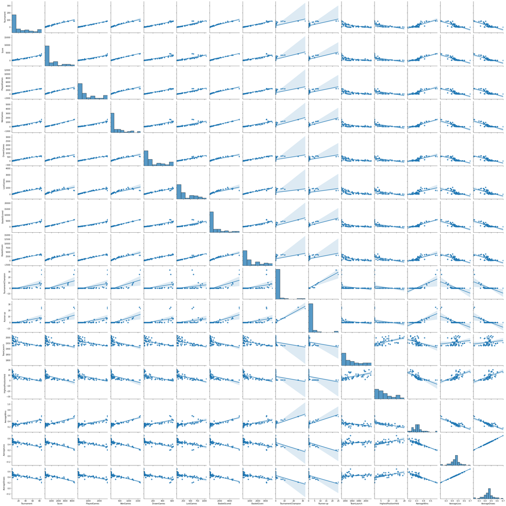

```python
import seaborn as sns

sns.pairplot(bbdata, kind="reg")  # plots scatter plots for every pair of attributes and histograms along the diagonal
plt.show()
```

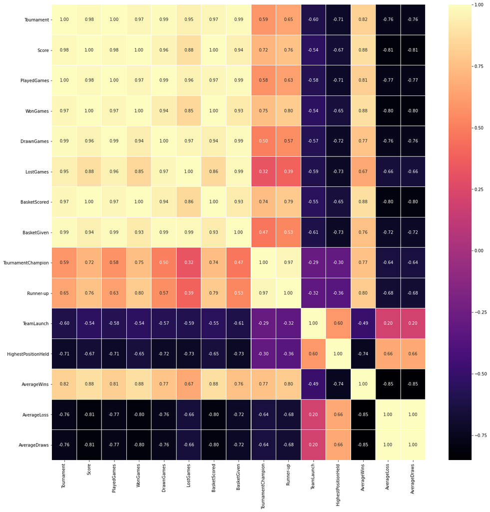

```python
fig,ax = plt.subplots(figsize=(20, 20))
sns.heatmap(bbdata.corr(), ax=ax, annot=True, linewidths=0.05, fmt= '.2f',cmap="magma") # the color intensity is based on
plt.show()
```

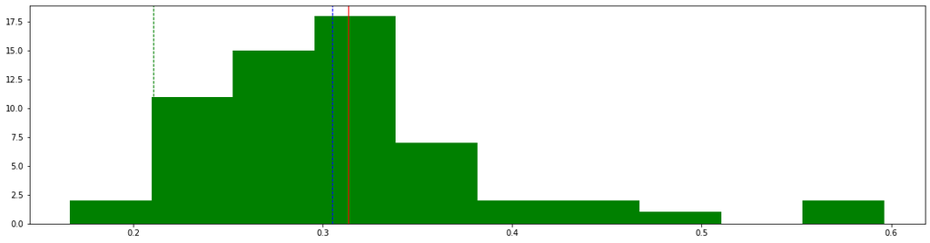

```python
plt.figure(figsize=(20,5)) # makes the plot wider
plt.hist(bbdata['AverageWins'], color='g') # plots a simple histogram
plt.axvline(bbdata['AverageWins'].mean(), color='r', linewidth=1)
plt.axvline(bbdata['AverageWins'].median(), color='b', linestyle='dashed', linewidth=1)
plt.axvline(bbdata['AverageWins'].mode()[0], color='g', linestyle='dashed', linewidth=1)
```

```python
## Number of PlayedGames v.s. Averagewins -
## Below scatterplot shows that if the team is playing more number of games, the percentage of their winning is increasing
```

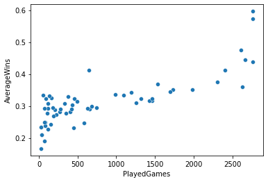

```python
sns.scatterplot(bbdata['PlayedGames'], bbdata['AverageWins'], palette='Set2')
```

```python
## Number of PlayedGames v.s. AverageLoss -
## Below scatterplot shows that if the team is playing more number of games,
# the percentage of their loss is decreasing. Few exceptions are visible though
```

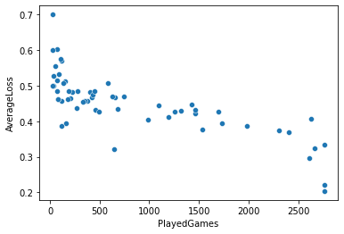

```python
sns.scatterplot(bbdata['PlayedGames'], bbdata['AverageLoss'], palette='Set2')
```

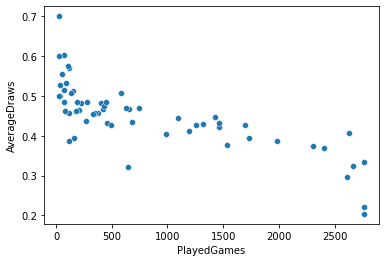

```python
sns.scatterplot(bbdata['PlayedGames'], bbdata['AverageDraws'], palette='Set2')
```

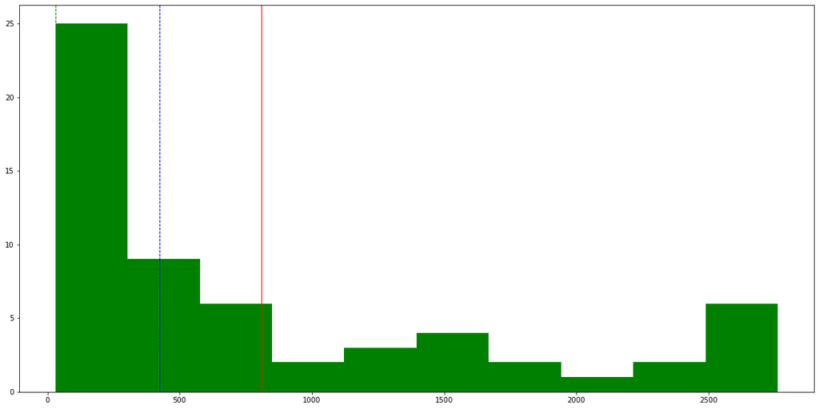

```python
plt.figure(figsize=(20,10)) # makes the plot wider
plt.hist(bbdata['PlayedGames'], color='g') # plots a simple histogram
plt.axvline(bbdata['PlayedGames'].mean(), color='r', linewidth=1)
plt.axvline(bbdata['PlayedGames'].median(), color='b', linestyle='dashed', linewidth=1)
plt.axvline(bbdata['PlayedGames'].mode()[0], color='g', linestyle='dashed', linewidth=1)
```

```python
## Above plot displays the density for the number of teams with less than 1000 played games.
## This means the overall experienced teams are less in number.
```

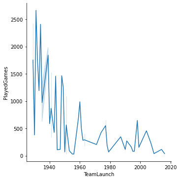

```python
sns.relplot(x="TeamLaunch", y="PlayedGames", kind="line",  data=bbdata)
```

```python
## This graph above is the analysis between TeamLaunch year and no of played games.
## Predominantly it shows that the Teams those are launched earlier are playing more games.
## This means that Teams launched earlier are playing more games now.
```

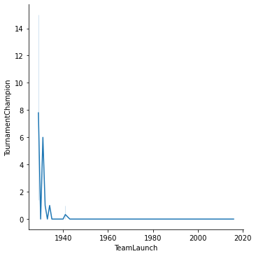

```python
sns.relplot(x="TeamLaunch", y="TournamentChampion", kind="line",  data=bbdata)
```

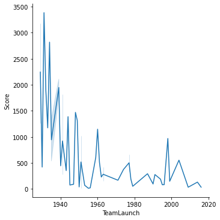

```python
## Graph above shows that teams laubched earlier (before 1940) have been Tournament champions predominantly.

sns.relplot(x="TeamLaunch", y="Score", kind="line",  data=bbdata)
```

```python
## Graph above shows that the scores are on higher side if Team Launched is earlier.
```

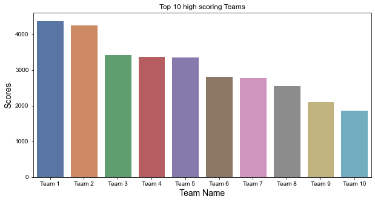

```python
final_df = bbdata.sort_values(by=['Score'], ascending=False)
final_df = final_df.head(10)
##carrier_count = bbdata['carrier'].value_counts()
fig, ax = plt.subplots(figsize=(10, 5))
sns.set(style="darkgrid")
sns.barplot(final_df['Team'], final_df['Score'])
plt.title('Top 10 high scoring Teams')
plt.ylabel('Scores' , fontsize=14)
plt.xlabel('Team Name', fontsize=14)
plt.show()
```

```python
## Team 1 is with the highest score
```

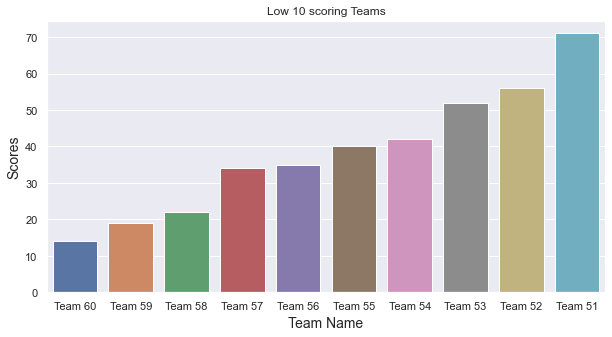

```python
final_df = bbdata.sort_values(by=['Score'], ascending=True)
final_df = final_df.head(10)

fig, ax = plt.subplots(figsize=(10, 5))
sns.set(style="darkgrid")
sns.barplot(final_df['Team'], final_df['Score'])
plt.title('Low 10 scoring Teams')
plt.ylabel('Scores' , fontsize=14)
plt.xlabel('Team Name', fontsize=14)
plt.show()
```

```python
## Team 60 is with the lowest score
```

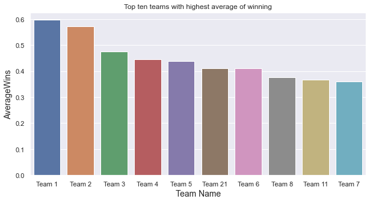

```python
final_df = bbdata.sort_values(by=['AverageWins'], ascending=False)
final_df = final_df.head(10)

fig, ax = plt.subplots(figsize=(10, 5))
sns.set(style="darkgrid")
sns.barplot(final_df['Team'], final_df['AverageWins'])
plt.title('Top ten teams with highest average of winning')
plt.ylabel('AverageWins' , fontsize=14)
plt.xlabel('Team Name', fontsize=14)
plt.show()
```

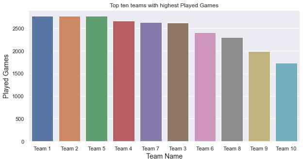

```python
final_df = bbdata.sort_values(by=['PlayedGames'], ascending=False)
final_df = final_df.head(10)

fig, ax = plt.subplots(figsize=(10, 5))
sns.set(style="darkgrid")
sns.barplot(final_df['Team'], final_df['PlayedGames'])
plt.title('Top ten teams with highest Played Games')
plt.ylabel('Played Games' , fontsize=14)
plt.xlabel('Team Name', fontsize=14)
plt.show()
```

```python
## Team 1, Team 2 and Team 5 are the one with highest number of games played
```

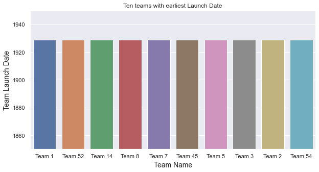

```python
final_df = bbdata.sort_values(by = ['TeamLaunch'], ascending=True)
final_df = final_df.head(10)

fig, ax = plt.subplots(figsize=(10, 5))
sns.set(style="darkgrid")
plot = sns.barplot(final_df['Team'], final_df['TeamLaunch'])
plot.set(ylim=(1850, 1950))
plt.title  ('Ten teams with earliest Launch Date')
plt.ylabel('Team Launch Date' , fontsize=14)
plt.xlabel('Team Name', fontsize=14)
plt.show()
```

```python
## Team 1, team 52, Team 14, Team 8, Team 7, Team 45, Team 5, Team 3, Team 2 and Team 54 are the one which are the oldest one
```

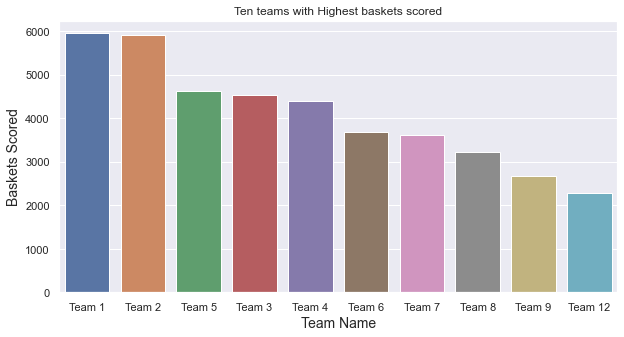

```python
final_df = bbdata.sort_values(by = ['BasketScored'], ascending=False)
final_df = final_df.head(10)

fig, ax = plt.subplots(figsize=(10, 5))
sns.set(style="darkgrid")
plot = sns.barplot(final_df['Team'], final_df['BasketScored'])
plt.title  ('Ten teams with Highest baskets scored')
plt.ylabel('Baskets Scored' , fontsize=14)
plt.xlabel('Team Name', fontsize=14)
plt.show()
```

```python
## Team 1 and Team 2 are the one with highest baskets scored.
```

# PART 3 : Project Based Assignment

## 1. Data warehouse:

```python
import numpy as np
import pandas as pd
import matplotlib.pyplot as plt

## Read CSV file
ccdataraw = pd.read_csv("DS - Part3 - CompanyX_EU.csv")
```

## 2. Data exploration:

```python
ccdataraw.head(5)
```

|  | Startup | Product | Funding | Event | Result | OperatingState |
| --- | --- | --- | --- | --- | --- | --- |
| 0 | 2600Hz | 2600hz.com | NaN | Disrupt SF 2013 | Contestant | Operating |
| 1 | 3DLT | 3dlt.com | $630K | Disrupt NYC 2013 | Contestant | Closed |
| 2 | 3DPrinterOS | 3dprinteros.com | NaN | Disrupt SF 2016 | Contestant | Operating |
| 3 | 3Dprintler | 3dprintler.com | $1M | Disrupt NY 2016 | Audience choice | Operating |
| 4 | 42 Technologies | 42technologies.com | NaN | Disrupt NYC 2013 | Contestant | Operating |

```python
ccdataraw.info()
```

```
<class 'pandas.core.frame.DataFrame'>
RangeIndex: 662 entries, 0 to 661
Data columns (total 6 columns):
 #   Column          Non-Null Count  Dtype
---  ------          --------------  -----
 0   Startup         662 non-null    object
 1   Product         656 non-null    object
 2   Funding         448 non-null    object
 3   Event           662 non-null    object
 4   Result          662 non-null    object
 5   OperatingState  662 non-null    object
dtypes: object(6)
memory usage: 31.2+ KB
```

```python
## Check duplicates
dupes = ccdataraw.duplicated()
sum(dupes)
```

```
0
```

```python
## No Duplicates
```

```python
## Check for null funding elements
EmptyFunding = pd.isnull(ccdataraw['Funding'])
sum(EmptyFunding)
```

```
214
```

```python
## Total 214 rows with empty funding values
## drop empty fundung rows
ccdatafmt = ccdataraw[ccdataraw['Funding'].notna()]

## Check if any empty funding calues present in formatted one
EmptyFunding = pd.isnull(ccdatafmt['Funding'])
sum(EmptyFunding)
```

```
0
```

## 3. Data preprocessing & visualisation:

```python
ccdatafmt.info()
```

```
<class 'pandas.core.frame.DataFrame'>
Int64Index: 448 entries, 1 to 661
Data columns (total 6 columns):
 #   Column          Non-Null Count  Dtype
---  ------          --------------  -----
 0   Startup         448 non-null    object
 1   Product         446 non-null    object
 2   Funding         448 non-null    object
 3   Event           448 non-null    object
 4   Result          448 non-null    object
 5   OperatingState  448 non-null    object
dtypes: object(6)
memory usage: 24.5+ KB
```

```python
ccdatafmt.head()
```

|  | Startup | Product | Funding | Event | Result | OperatingState |
| --- | --- | --- | --- | --- | --- | --- |
| 1 | 3DLT | 3dlt.com | $630K | Disrupt NYC 2013 | Contestant | Closed |
| 3 | 3Dprintler | 3dprintler.com | $1M | Disrupt NY 2016 | Audience choice | Operating |
| 5 | 5to1 | 5to1.com | $19.3M | TC50 2009 | Contestant | Acquired |
| 6 | 8 Securities | 8securities.com | $29M | Disrupt Beijing 2011 | Finalist | Operating |
| 10 | AdhereTech | adheretech.com | $1.8M | Hardware Battlefield 2014 | Contestant | Operating |

```python
## Lamda function handy to identy the the type of the variable passed
lambda x: type(x).__name__
```

```
<function __main__.<lambda>(x)>
```

```python
ccdatafmtcpy = ccdatafmt.copy()
ccdatafmtcpy['Funding'].apply(type).value_counts()
```

```
<class 'str'>    448
Name: Funding, dtype: int64
```

```python
## All the currency values are of type string based on above output
## Need to get rid of $ at the beginning of the string. Write a function for the same
def clean_currency(x):
    """ If the value is a string, then remove currency symbol and delimiters
    otherwise, the value is numeric and can be converted
    """
    if isinstance(x, str):
        return(x.replace('$', '').replace(',', ''))
    return(x)

ccdatafmt['Funding'] = ccdatafmt['Funding'].apply(clean_currency)
```

```python
ccdatafmt.head(25)
```

|  | Startup | Product | Funding | Event | Result | OperatingState |
| --- | --- | --- | --- | --- | --- | --- |
| 1 | 3DLT | 3dlt.com | 630K | Disrupt NYC 2013 | Contestant | Closed |
| 3 | 3Dprintler | 3dprintler.com | 1M | Disrupt NY 2016 | Audience choice | Operating |
| 5 | 5to1 | 5to1.com | 19.3M | TC50 2009 | Contestant | Acquired |
| 6 | 8 Securities | 8securities.com | 29M | Disrupt Beijing 2011 | Finalist | Operating |
| 10 | AdhereTech | adheretech.com | 1.8M | Hardware Battlefield 2014 | Contestant | Operating |
| 11 | AdRocket | adrocket.com | 1M | TC50 2008 | Contestant | Closed |
| 13 | Agrilyst | agrilyst.com | 1M | Disrupt SF 2015 | Winner | Operating |
| 14 | Aiden | aiden.ai | 750K | Disrupt London 2016 | Contestant | Operating |
| 15 | AirBoxLab | foobot.io | 17.9K | Hardware Battlefield 2014 | Contestant | Operating |
| 16 | Aircall | aircall.io | 11.6M | Disrupt SF 2015 | Contestant | Operating |
| 17 | AirDroids | airdroids.com | 929.2K | Hardware Battlefield 2014 | Contestant | Closed |
| 18 | AirHelp | airhelp.com | 12.2M | Disrupt NYC 2014 | Contestant | Operating |
| 20 | Akoha | akoha.com | 1.9M | TC50 2008 | Contestant | Closed |
| 22 | Alicanto | alicanto.com | 4M | Disrupt SF 2012 | Contestant | Operating |
| 27 | Amen. | getamen.com | 3M | Disrupt SF 2011 | Contestant | Acquired |
| 28 | Angstro | angst.ro | 225K | TC50 2008 | Contestant | Acquired |
| 31 | Anyclip | anyclip.com | 24M | TC50 2009 | Finalist | Operating |
| 32 | App2you | app2you.com | 746K | TC40 2007 | Contestant | Operating |
| 34 | Appbistro | appbistro.com | 600K | Disrupt NYC 2010 | Contestant | Closed |
| 35 | AppChina | appchina.com | 7.1M | Disrupt Beijing 2011 | Contestant | Operating |
| 37 | Ark | ark.com | 4.5M | Disrupt NYC 2012 | Finalist | Operating |
| 40 | Artsy | artsy.net | 50.9M | Disrupt NYC 2010 | Contestant | Operating |
| 42 | asap54.com | asap54.com | 8.3M | Disrupt EU 2013 | Runner up | Operating |
| 44 | Atlas Wearables | atlaswearables.com | 4M | Hardware Battlefield 2014 | Finalist | Operating |
| 46 | Ava | avawomen.com | 12.3M | Disrupt SF 2015 | Contestant | Operating |

```python
## All the currency values are of type string
## Need to convert into numerical by removing K and M by applying right multification factor

## This function takes a value as x and if it is string, it will convert to float by multiplying with
## right factor (1000 for K, 1000000 for M and so on)
def value_to_float(x):
    if type(x) == float or type(x) == int:
        return x
    if 'K' in x:
        if len(x) > 1:
            return float(x.replace('K', '')) * 1000
        return 1000
    if 'M' in x:
        if len(x) > 1:
            return float(x.replace('M', '')) * 1000000
        return 1000000
    if 'B' in x:
        return float(x.replace('B', '')) * 1000000000
    return 0

## Apply function to all values of column 'Funding'
ccdatafmt['Funding'] = ccdatafmt['Funding'].apply(value_to_float)

ccdatafmt.tail(25)
```

|  | Startup | Product | Funding | Event | Result | OperatingState |
| --- | --- | --- | --- | --- | --- | --- |
| 629 | WaterO | wateropurifier.com | 85700.0 | Disrupt NY 2016 | Runner up | Operating |
| 630 | WAZER | wazer.com | 1400000.0 | Disrupt SF 2016 | Contestant | Operating |
| 631 | WEconnect | weconnectrecovery.com | 2100000.0 | Disrupt SF 2016 | Audience choice | Operating |
| 632 | WeDemand | wedemand.com | 1000000.0 | Disrupt SF 2012 | Contestant | Operating |
| 633 | Wellth | wellthapp.com | 2500000.0 | Disrupt NY 2015 | Contestant | Operating |
| 634 | Wellthy | wellthy.com | 2000000.0 | Disrupt SF 2015 | Contestant | Operating |
| 635 | Welltwigs | welltwigs.com | 50000.0 | Disrupt NY 2015 | Contestant | Operating |
| 638 | Wiivv | wiivv.com | 12200000.0 | Hardware Battlefield 2016 | Runner up | Operating |
| 640 | WooMe | woome.com | 17400000.0 | TC40 2007 | Finalist | Acquired |
| 641 | Workspot | workspot.com | 15800000.0 | Disrupt NYC 2013 | Contestant | Operating |
| 642 | Xendo | xendo.com | 28000.0 | Disrupt SF 2014 | Contestant | Acquired |
| 643 | Xobni | yahoo.com | 41800000.0 | TC40 2007 | Contestant | Acquired |
| 644 | Yammer | yammer.com | 142000000.0 | TC50 2008 | Winner | Acquired |
| 645 | Yap | yapme.com | 10000000.0 | TC40 2007 | Contestant | Closed |
| 646 | YayPay Inc | yaypay.com | 900000.0 | Disrupt London 2015 | Contestant | Operating |
| 647 | Yext | yext.com | 117800000.0 | TC50 2009 | Contestant | Ipo |
| 649 | YouNow | younow.com | 26000000.0 | Disrupt SF 2011 | Contestant | Operating |
| 650 | YourMechanic | yourmechanic.com | 28000000.0 | Disrupt SF 2012 | Winner | Operating |
| 654 | ZEFR | zefr.com | 62100000.0 | Disrupt NYC 2010 | Contestant | Operating |
| 656 | Zenefits | zenefits.com | 583600000.0 | Disrupt NYC 2013 | Finalist | Operating |
| 657 | Zivity | zivity.com | 8000000.0 | TC40 2007 | Contestant | Operating |
| 658 | Zmorph | zmorph3d.com | 1000000.0 | - | Audience choice | Operating |
| 659 | Zocdoc | zocdoc.com | 223000000.0 | TC40 2007 | Contestant | Operating |
| 660 | Zula | zulaapp.com | 3400000.0 | Disrupt SF 2013 | Audience choice | Operating |
| 661 | Zumper | zumper.com | 31500000.0 | Disrupt SF 2012 | Finalist | Operating |

```python
## Check the data type for Funding variable
ccdatafmt.info()
```

```
<class 'pandas.core.frame.DataFrame'>
Int64Index: 448 entries, 1 to 661
Data columns (total 6 columns):
 #   Column          Non-Null Count  Dtype
---  ------          --------------  -----
 0   Startup         448 non-null    object
 1   Product         446 non-null    object
 2   Funding         448 non-null    float64
 3   Event           448 non-null    object
 4   Result          448 non-null    object
 5   OperatingState  448 non-null    object
dtypes: float64(1), object(5)
memory usage: 24.5+ KB
```

```python
ccdatafmtcpy = ccdatafmt.copy()
ccdatafmtcpy['Funding'].apply(type).value_counts()
## Check the data type for each variable of type 'Funding' and confirm it is float
```

```
<class 'float'>    448
Name: Funding, dtype: int64
```

```python
## Convert funding tatatype to numeric as all values are float
ccdatafmt['Funding'] = ccdatafmt['Funding'].apply(pd.to_numeric)
```

```python
## Check the data type for Funding variable
ccdatafmt.info()
```

```
<class 'pandas.core.frame.DataFrame'>
Int64Index: 448 entries, 1 to 661
Data columns (total 6 columns):
 #   Column          Non-Null Count  Dtype
---  ------          --------------  -----
 0   Startup         448 non-null    object
 1   Product         446 non-null    object
 2   Funding         448 non-null    float64
 3   Event           448 non-null    object
 4   Result          448 non-null    object
 5   OperatingState  448 non-null    object
dtypes: float64(1), object(5)
memory usage: 24.5+ KB
```

```python
## Add a new column for funds in million
ccdatafmt['FundingInMillion'] = ccdatafmt['Funding']/1000000
```

```python
ccdatafmt.info()
```

```
<class 'pandas.core.frame.DataFrame'>
Int64Index: 448 entries, 1 to 661
Data columns (total 7 columns):
 #   Column            Non-Null Count  Dtype
---  ------            --------------  -----
 0   Startup           448 non-null    object
 1   Product           446 non-null    object
 2   Funding           448 non-null    float64
 3   Event             448 non-null    object
 4   Result            448 non-null    object
 5   OperatingState    448 non-null    object
 6   FundingInMillion  448 non-null    float64
dtypes: float64(2), object(5)
memory usage: 28.0+ KB
```

```python
ccdatafmt.head(5)
```

|  | Startup | Product | Funding | Event | Result | OperatingState | FundingInMillion |
| --- | --- | --- | --- | --- | --- | --- | --- |
| 1 | 3DLT | 3dlt.com | 630000.0 | Disrupt NYC 2013 | Contestant | Closed | 0.63 |
| 3 | 3Dprintler | 3dprintler.com | 1000000.0 | Disrupt NY 2016 | Audience choice | Operating | 1.00 |
| 5 | 5to1 | 5to1.com | 19300000.0 | TC50 2009 | Contestant | Acquired | 19.30 |
| 6 | 8 Securities | 8securities.com | 29000000.0 | Disrupt Beijing 2011 | Finalist | Operating | 29.00 |
| 10 | AdhereTech | adheretech.com | 1800000.0 | Hardware Battlefield 2014 | Contestant | Operating | 1.80 |

```python
ccdatafmt.describe()
```

|  | Funding | FundingInMillion |
| --- | --- | --- |
| count | 4.480000e+02 | 448.000000 |
| mean | 1.718237e+07 | 17.182375 |
| std | 9.028540e+07 | 90.285396 |
| min | 5.000000e+03 | 0.005000 |
| 25% | 7.457500e+05 | 0.745750 |
| 50% | 2.250000e+06 | 2.250000 |
| 75% | 9.425000e+06 | 9.425000 |
| max | 1.700000e+09 | 1700.000000 |

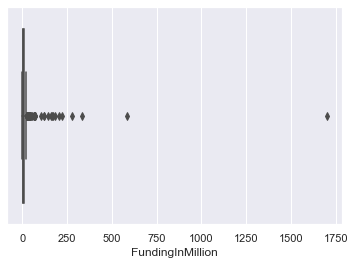

```python
## Five point summary for Funding values as above
sns.boxplot (ccdatafmt["FundingInMillion"])
```

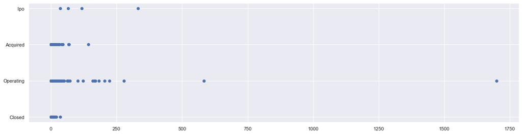

```python
## Let's draw a scatterplot to identify outliers

fig, ax = plt.subplots(figsize=(20, 5))
ax.scatter (ccdatafmt['FundingInMillion'],ccdatafmt['OperatingState'])
plt.show()
```

```python
## Remove values with less than million dollars from the dataframe
## only the values with million or higher will be considered for calculations (this is the assumption made)

ccdatafmtorig = ccdatafmt.copy() ## Keep the original copy of the entire dataset
ccdatafmt = ccdatafmt[ccdatafmt['FundingInMillion'] > 1].copy()
```

```python
## Identify outliers in FundingInMillion column of the data frame
from scipy import stats
import numpy as np

FundInMillionDf = ccdatafmt['FundingInMillion'].copy()
```

```python
## Calculate
Q1 = FundInMillionDf.quantile(0.25)
Q3 = FundInMillionDf.quantile(0.75)
IQR = Q3 - Q1
print('IQR:', IQR)
print ('Q1:',Q1)
print ('Q3:', Q3)
```

```
IQR: 14.0
Q1: 2.3
Q3: 16.3
```

```python
np.where((FundInMillionDf < (Q1 - 1.5 * IQR))| (FundInMillionDf > (Q3 + 1.5 * IQR)))
```

```
(array([ 11,  15,  18,  42,  52,  55,  56,  63,  81,  91,  99, 118, 122,
        125, 137, 139, 142, 178, 193, 200, 214, 240, 243, 258, 264, 283,
        284, 286, 289, 290, 292]),)
```

```python
## Rows with FundsInMillion - outliers at the higher side
##FundInMillionDf(np.where(FundInMillionDf > (Q3 + 1.5 * IQR)))

print ("Higher bound (FundsInMillion)", Q3 + 1.5 * IQR)
print ("Lower bound (FundsInMillion)", Q1 - 1.5 * IQR)
## Add an additional column in the main dataframe to indicate if this data is beyond outlier
## Set the default value to 0
ccdatafmt['FundInMillionOutlier'] = 0

for i in np.where(FundInMillionDf > Q3 + 1.5 * IQR):
    print ( "Outlier on a higher side:",FundInMillionDf.iloc[i])
    ccdatafmt['FundInMillionOutlier'].iloc[i] = 1


## Rows with FundsInMillion - outliers at the lower side
for i in np.where(FundInMillionDf < Q1 - 1.5 * IQR):
    print ( "Outlier on a lower side:",FundInMillionDf.iloc[i])
    ccdatafmt['FundInMillionOutlier'].iloc[i] = 1
```

```
Higher bound (FundsInMillion) 37.3
Lower bound (FundsInMillion) -18.7
Outlier on a higher side: 40       50.9
49       40.0
56      205.0
113     182.1
130      38.0
138      72.0
139      64.0
154    1700.0
188      66.0
209     103.0
225      44.7
271     122.4
279      67.8
```

[output cut: 20 more lines]

```python
## Remove the values beyond lower and outer bounds
## Create a copy for the same
ccdatafmtcpy = ccdatafmt[ccdatafmt['FundInMillionOutlier'] == 0].copy()

ccdatafmtcpy.shape
ccdatafmt.shape
ccdatafmtcpy.shape
```

```
(264, 8)
```

#### Boxplot plotting after outliers in FundsInMillion are removed

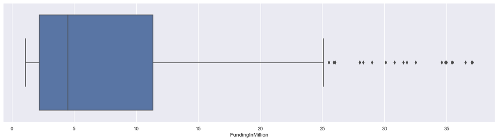

```python
## Boxplot for the values where outliers on a higher side are removed
fig, ax = plt.subplots(figsize=(20, 5))
sns.boxplot (ccdatafmtcpy["FundingInMillion"])
```

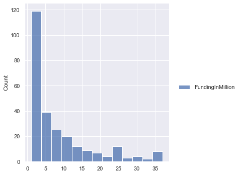

```python
## Distribution plots for Funds in millions
##fig, ax = plt.subplots(figsize=(20, 5))
data = pd.DataFrame(ccdatafmtcpy["FundingInMillion"])
res = sns.displot(data)
```

#### Frequency of the OperatingState features classes.

```python
##OperatingState Distribution

print (ccdatafmtorig['OperatingState'].value_counts())
ccdatafmtorig['OperatingState'].count()
```

```
Operating    320
Acquired      66
Closed        58
Ipo            4
Name: OperatingState, dtype: int64
```

```
448
```

```python
## Frequency distribution using group by
OperatingStateFreqDist = ccdatafmtorig.groupby("OperatingState")["OperatingState"].count()
print(OperatingStateFreqDist)
```

```
OperatingState
Acquired      66
Closed        58
Ipo            4
Operating    320
Name: OperatingState, dtype: int64
```

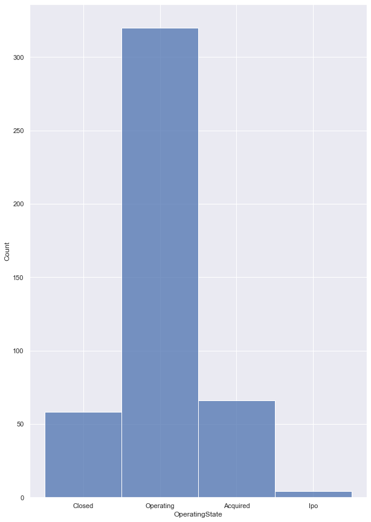

```python
## OperatingState Distribution plotted in histogram
fig, ax = plt.subplots(figsize=(10, 15))
res = sns.histplot(ccdatafmtorig["OperatingState"])
```

## 4. Statistical analysis:

### Analysis of Funds raised by companies that are still operating vs companies that closed down

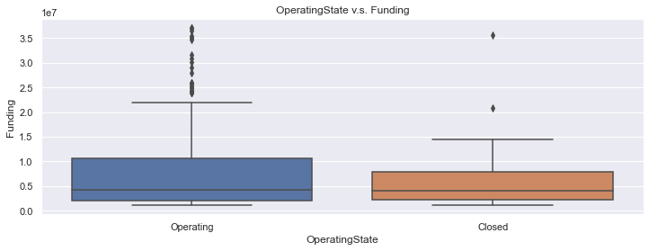

```python
## Use the processed dataframe (with outliers removed)

## Create two seperate data frames (one for companies operating and one for the ones closed down)
ccdatafmtoperating = ccdatafmtcpy[ccdatafmtcpy['OperatingState'] == 'Operating']
ccdatafmtclosed = ccdatafmtcpy[ccdatafmtcpy['OperatingState'] == 'Closed']

ccdatafmt_Operating_Closed = pd.DataFrame()

ccdatafmt_Operating_Closed = ccdatafmt_Operating_Closed.append(ccdatafmtoperating)
ccdatafmt_Operating_Closed = ccdatafmt_Operating_Closed.append(ccdatafmtclosed)

## Box plots for the data for qualitative analysis
fig, ax = plt.subplots(figsize=(12, 4))
sns.boxplot(x = "OperatingState", y = "Funding", data = ccdatafmt_Operating_Closed)
plt.title('OperatingState v.s. Funding')
plt.show()
```

### Null and Alternate Hypothesis

##### Null Hypothesis

Funding position for Operating and Closed companies follow the similar distribution

#### Alternae Hypothesis

Funding position for Operating and Closed companies have different distributions

#### Significance Level

Here we select α = 0.05

#### Test Statistics

We are having a categorical variable (OperatingState) and one continuous variable (Funding) and we want to validate curve for two different values of the categrical variable. This qualifies for Innova test

```python
import statsmodels.api         as     sm
from   statsmodels.formula.api import ols

mod = ols('Funding ~ OperatingState', data = ccdatafmt_Operating_Closed).fit()
aov_table = sm.stats.anova_lm(mod, typ=2)
print(aov_table)
```

```
                      sum_sq     df         F    PR(>F)
OperatingState  5.093102e+13    1.0  0.666443  0.415198
Residual        1.643076e+16  215.0       NaN       NaN
```

Here the P value is 0.415198 which is far higher than our level of Significance (0.05) So we fail to reject the hypothesis.

The inference is that from the data provided the funding position for both closed and Operating companies do not have significance difference

#### Frequency Distribution for the 'Results' column

```python
print ('Frequency Distribution for the ''Results'' column from original dataframe:')
print (ccdatafmtorig['Result'].value_counts())
```

```
Frequency Distribution for the Results column from original dataframe:
Contestant         314
Finalist            65
Audience choice     25
Winner              25
Runner up           19
Name: Result, dtype: int64
```

#### Percentage of winners that are still operating and percentage of contestants that are still operating

```python
## Create a data frame with OperatingState as Operating
ccdatafmt_Operating = ccdatafmtorig[ccdatafmtorig['OperatingState'] == 'Operating']
print (ccdatafmt_Operating['Result'].value_counts())
ccdatafmt_Operating['Result'].count()
```

```
Contestant         215
Finalist            46
Audience choice     23
Runner up           18
Winner              18
Name: Result, dtype: int64
```

```
320
```

```python
## Percentage of winners and contestants who are still operating
PercentWinners = 18/320 * 100
PercentContestant = 215/320 * 100

print ("Percentage of winners who are operating:", PercentWinners)

print ("Percentage of Contestants who are operating:", PercentContestant)
```

[output not shown]

#### Proportion of companies that are operating between winners and contestants

###### Null Hypothesis:

Proportion of companies operating between winners and contestants are equal

###### Alternate Hypothesis:

Proportion of companies operating between winners and contestants differ

```python
## No of winners who are operating
nOperating_Winners = ccdatafmt_Operating[ccdatafmt_Operating['Result'] == 'Winner'].Result.value_counts()[0]
## No of Contestants who are operating
nOperating_Contestants = ccdatafmt_Operating[ccdatafmt_Operating['Result'] == 'Contestant'].Result.value_counts()[0]
## No of total winners
nTotal_Winners = ccdatafmtorig[ccdatafmtorig['Result'] == 'Winner'].Result.value_counts()[0]
## No of total Contestants
nTotal_Contestants = ccdatafmtorig[ccdatafmtorig['Result'] == 'Contestant'].Result.value_counts()[0]

print ('Total winners who are operating:', nOperating_Winners)

print ('Total contestants who are operating:', nOperating_Contestants)
print ('Total winners:', nTotal_Winners)
print ('Total contestants:', nTotal_Contestants)
```

```
Total winners who are operating: 18
Total contestants who are operating: 215
Total winners: 25
Total contestants: 314
```

##### Test of proportion needs to be applied here:

```python
from statsmodels.stats.proportion import proportions_ztest

stat, pval = proportions_ztest([nOperating_Winners, nOperating_Contestants] , [nTotal_Winners, nTotal_Contestants])

print ('pval is:', pval)

if pval < 0.05:
    print(f'With a p-value of {round(pval,4)} the difference is significant. Null hypothesis is rejected')
else:
    print(f'With a p-value of {round(pval,4)} the difference is not significant. We fail to reject null hypothesis')
```

```
pval is: 0.7141557169869068
With a p-value of 0.7142 the difference is not significant. We fail to reject null hypothesis
```

### Distribution of Event variable

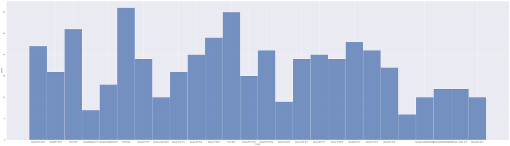

```python
## plot the histplot for event
fig, ax = plt.subplots(figsize=(60, 17))
import seaborn as sns
res = sns.histplot(ccdatafmtorig["Event"])
```

```python
print (ccdatafmtorig['Event'].value_counts())
ccdatafmt_Operating['Result'].count()
```

```
TC50 2008                    31
TC40 2007                    30
TC50 2009                    26
Disrupt SF 2011              24
Disrupt SF 2013              23
Disrupt NYC 2013             22
Disrupt NY 2015              21
Disrupt NYC 2012             21
Disrupt SF 2010              20
Disrupt SF 2012              20
Disrupt SF 2014              19
Disrupt SF 2015              19
Disrupt NYC 2011             19
Disrupt SF 2016              17
Disrupt NY 2016              16
Disrupt NYC 2014             16
Disrupt NYC 2010             15
Hardware Battlefield 2014    13
Hardware Battlefield 2016    12
Disrupt London 2015          12
Hardware Battlefield 2015    10
Disrupt London 2016          10
Disrupt EU 2014              10
Disrupt EU 2013               9
Disrupt Beijing 2011          7
-                             6
Name: Event, dtype: int64
```

```
320
```

### Select only the Event that has disrupt keyword from 2013 onwards

```python
keywords_to_check = ['2013','2014','2015','2016']
ccdatafmt_disrupt2013 = ccdatafmtorig[ccdatafmtorig['Event'].str.contains('|'.join(keywords_to_check))]

keywords_to_check = ['Disrupt']
ccdatafmt_disrupt2013 = ccdatafmt_disrupt2013[ccdatafmt_disrupt2013['Event'].str.contains('|'.join(keywords_to_check))]

## ccdatafmt_disrupt2013 this variable has rows with Event as disrupt keyword from 2013 onwards

print (ccdatafmt_disrupt2013['Event'].value_counts())
```

```
Disrupt SF 2013        23
Disrupt NYC 2013       22
Disrupt NY 2015        21
Disrupt SF 2015        19
Disrupt SF 2014        19
Disrupt SF 2016        17
Disrupt NYC 2014       16
Disrupt NY 2016        16
Disrupt London 2015    12
Disrupt London 2016    10
Disrupt EU 2014        10
Disrupt EU 2013         9
Name: Event, dtype: int64
```

### Hypothesis along with significance test comparing the funds raised by companies across NY, SF and EU events from 2013 onwards.

```python
## We will use the formatted data with funding outliers removed for this exercise
## First identify rows with SF, NY, NYC or EU events
keywords_to_check = ['SF','NY','NYC','EU']
ccdatafmt_NYSFEU = ccdatafmtcpy[ccdatafmtcpy['Event'].str.contains('|'.join(keywords_to_check))]

## Now filter on 2013 or onwards rows from the rows with SF, NY, NYC or EU events
keywords_to_check = ['2013','2014','2015','2016']
ccdatafmt_NYSFEU_filtered = ccdatafmt_NYSFEU[ccdatafmt_NYSFEU['Event'].str.contains('|'.join(keywords_to_check))]
print (ccdatafmt_NYSFEU_filtered['Event'].value_counts())
```

```
Disrupt NYC 2013    16
Disrupt SF 2013     14
Disrupt SF 2014     13
Disrupt NY 2015     12
Disrupt SF 2016     12
Disrupt NYC 2014    10
Disrupt NY 2016      8
Disrupt SF 2015      7
Disrupt EU 2013      6
Disrupt EU 2014      4
Name: Event, dtype: int64
```

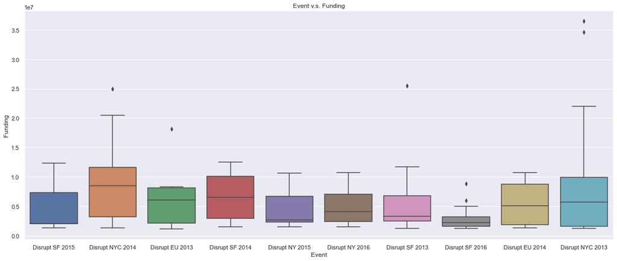

```python
## Qualitative analysis by plotting Box Plots for this distribution

fig, ax = plt.subplots(figsize=(20, 8))
sns.boxplot(x = "Event", y = "Funding", data = ccdatafmt_NYSFEU_filtered)
plt.title('Event v.s. Funding')
plt.show()
```

#### Null and Alternate Hypothesis

##### Null Hypothesis

Funding position for companies across NY, EU and SF post 2013 follow the similar distribution

##### Alternae Hypothesis

Funding position for companies across NY, EU and SF post 2013 have different distribution

##### Significance Level

Here we select α = 0.05

##### Test Statistics

```python
import statsmodels.api         as     sm
from   statsmodels.formula.api import ols

mod = ols('Funding ~ OperatingState', data = ccdatafmt_NYSFEU_filtered).fit()
aov_table = sm.stats.anova_lm(mod, typ=2)
print(aov_table)
```

```
                      sum_sq    df         F    PR(>F)
OperatingState  5.475667e+13   2.0  0.617246  0.541491
Residual        4.391209e+15  99.0       NaN       NaN
```

#### Plots to showcase the distribution of fundings across 3 city events

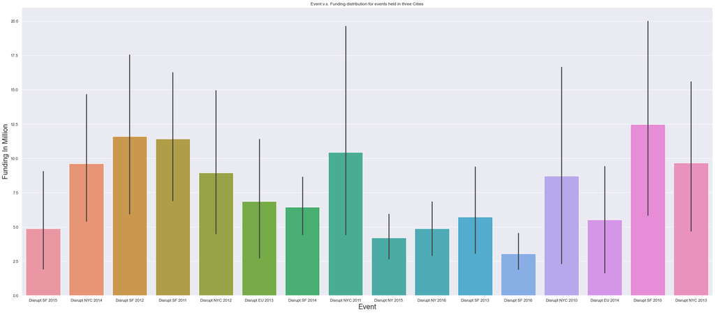

```python
## Distribution plots for Funds in millions
##fig, ax = plt.subplots(figsize=(20, 5))

fig, ax = plt.subplots(figsize=(35, 15))
sns.set(style="darkgrid")
plot = sns.barplot(ccdatafmt_NYSFEU['Event'], ccdatafmt_NYSFEU['FundingInMillion'])
plt.title  ('Event v.s. Funding distribution for events held in three Cities')
plt.ylabel('Funding In Million' , fontsize=20)
plt.xlabel('Event', fontsize=20)
plt.show()
```

## 5. Suggestions on data quality

- Numerical data (currency in this case) should only be provided in numerical figures and figures like $ or K or M should be avoided
- In the text data, please try to provide all the details (for example in few cases the names of Events were missing and only - was provided